# BANK CAMPAIGN ANALYSIS

Nolan Cardozo

25 January 2017

## Data

The `Bank Campaign` data set contains a campaign run by the bank and the response from the campaign. It contains a collection of variable given as follows.

Some of the variables in the `Bank Campaign` data set are: *(Also classifying them into(Dimensions, Metrics, Dates, Text and Geo))*

- **Age Group** - The Age Group of the respondents of the campaign.**(Dimension)**
- **Job** - The Job Title of the respondents of the campaign.**(Dimension)**
- **Marital** - The Marital Status of the respondents of the campaign.**(Dimension)**
- **Education** - The Highest Educational Qualification of the respondents of the campaign. **(Dimension)**
- **Balance Group** - The income group to which the respondents of the campaign belongs to. **(Dimension)**
- **Month** - The Month in which the campaign was run. **(Date)**
- **Response Rate** - It captures data whether the respondent responded to the campaign or not. **(Can be both Dimension and metric but makes more sense as dimension)**

## Reading the dataset into R

```r
Bank.Campaign <- read.csv("C:/Users/Admin/Desktop/data visulisation/Bank Campaign.csv")
```

## Inspecting the first and last 6 rows of the data for better undertanding of contents

```r
head(Bank.Campaign)
```

```
##   Age.Group          Job Marital Education Default Balance.Group Month
## 1       50+   management married  tertiary      no        medium   may
## 2       40+   technician  single secondary      no           low   may
## 3       30+ entrepreneur married secondary      no           low   may
## 4       40+  blue-collar married   unknown      no        medium   may
## 5       30+      unknown  single   unknown      no           low   may
## 6       30+   management married  tertiary      no           low   may
##   Response.Rate
## 1             0
## 2             0
## 3             0
## 4             0
## 5             0
## 6             0
```

```r
tail(Bank.Campaign)
```

```
##       Age.Group          Job  Marital Education Default Balance.Group
## 45206       20+   technician   single secondary      no           low
## 45207       50+   technician  married  tertiary      no           low
## 45208       70+      retired divorced   primary      no        medium
## 45209       70+      retired  married secondary      no        medium
## 45210       50+  blue-collar  married secondary      no           low
## 45211       30+ entrepreneur  married secondary      no        medium
##       Month Response.Rate
## 45206   nov             1
## 45207   nov             1
## 45208   nov             1
## 45209   nov             1
## 45210   nov             0
## 45211   nov             0
```

## Inspecting the structure and frequency of the data

```r
str(Bank.Campaign)
```

```
## 'data.frame':    45211 obs. of  8 variables:
##  $ Age.Group    : Factor w/ 9 levels "10+","20+","30+",..: 5 4 3 4 3 3 2 4 5 4 ...
##  $ Job          : Factor w/ 12 levels "admin.","blue-collar",..: 5 10 3 2 12 5 5 3 6 10 ...
##  $ Marital      : Factor w/ 3 levels "divorced","married",..: 2 3 2 2 3 2 3 1 2 3 ...
##  $ Education    : Factor w/ 4 levels "primary","secondary",..: 3 2 2 4 4 3 3 3 1 2 ...
##  $ Default      : Factor w/ 2 levels "no","yes": 1 1 1 1 1 1 1 2 1 1 ...
##  $ Balance.Group: Factor w/ 3 levels "high","low","medium": 3 2 2 3 2 2 2 2 2 2 ...
##  $ Month        : Factor w/ 12 levels "apr","aug","dec",..: 9 9 9 9 9 9 9 9 9 9 ...
##  $ Response.Rate: int  0 0 0 0 0 0 0 0 0 0 ...
```

## The number of rows and columns in the dataset

```r
dim(Bank.Campaign)
```

```
## [1] 45211     8
```

## Running basic summary statistics on the data

```r
summary(Bank.Campaign,maxsum=15)
```

```
##  Age.Group              Job           Marital          Education
##  10+:   47   admin.       :5171   divorced: 5207   primary  : 6851
##  20+: 5226   blue-collar  :9732   married :27214   secondary:23202
##  30+:18089   entrepreneur :1487   single  :12790   tertiary :13301
##  40+:11655   housemaid    :1240                    unknown  : 1857
##  50+: 8410   management   :9458
##  60+: 1230   retired      :2264
##  70+:  424   self-employed:1579
##  80+:  121   services     :4154
##  90+:    9   student      : 938
##              technician   :7597
##              unemployed   :1303
##              unknown      : 288
##  Default     Balance.Group  Month       Response.Rate
##  no :44396   high  :  829   apr: 2932   Min.   :0.000
##  yes:  815   low   :30569   aug: 6247   1st Qu.:0.000
##              medium:13813   dec:  214   Median :0.000
##                             feb: 2649   Mean   :0.117
##                             jan: 1403   3rd Qu.:0.000
##                             jul: 6895   Max.   :1.000
##                             jun: 5341
##                             mar:  477
##                             may:13766
##                             nov: 3970
##                             oct:  738
##                             sep:  579
```

## Checking for NA’s in the dataset visually using package VIM and function aggr

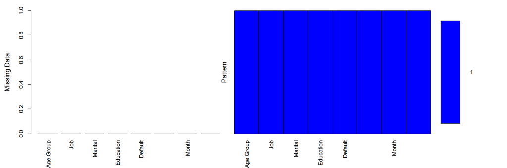

```
##
##  Variables sorted by number of missings:
##       Variable Count
##      Age.Group     0
##            Job     0
##        Marital     0
##      Education     0
##        Default     0
##  Balance.Group     0
##          Month     0
##  Response.Rate     0
```

```r
missing_plot<-aggr(Bank.Campaign,col=c('blue','red'),
                      numbers=TRUE,sortVars=TRUE,
                      labels=names(Bank.Campaign),gap=1,
                      ylab=c("Missing Data","Pattern"), plot=TRUE)
```

##### The above head map and histogram shows no null values in the dataset

### The count of all non null values in each column

```r
as.data.frame(sapply(Bank.Campaign,function(y) sum(length(which(!is.na(y))))))
```

```
##               sapply(Bank.Campaign, function(y) sum(length(which(!is.na(y)))))
## Age.Group                                                                45211
## Job                                                                      45211
## Marital                                                                  45211
## Education                                                                45211
## Default                                                                  45211
## Balance.Group                                                            45211
## Month                                                                    45211
## Response.Rate                                                            45211
```

##### The above figure shows no null values in the dataset

## The frequency plots for all the dimensions are as follows:

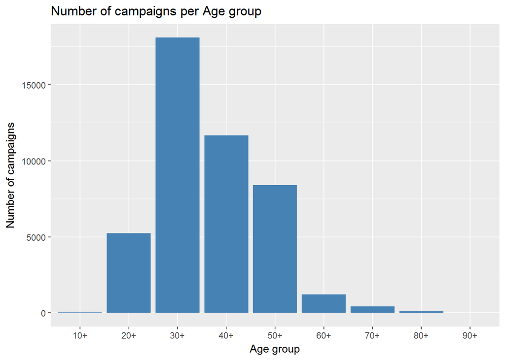

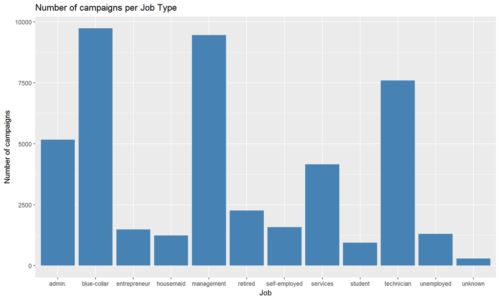

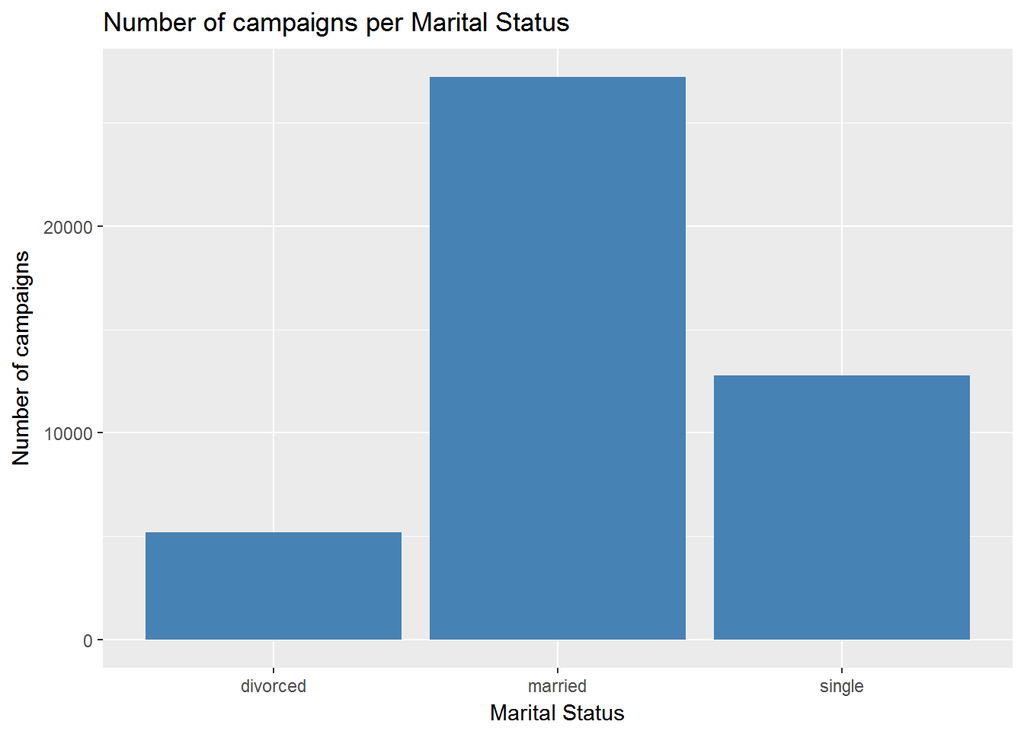

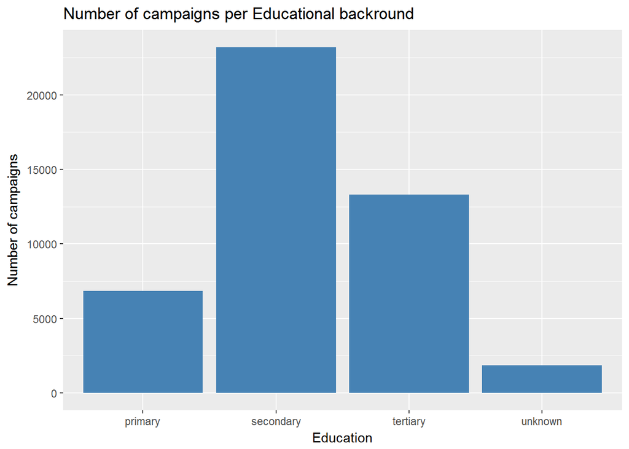

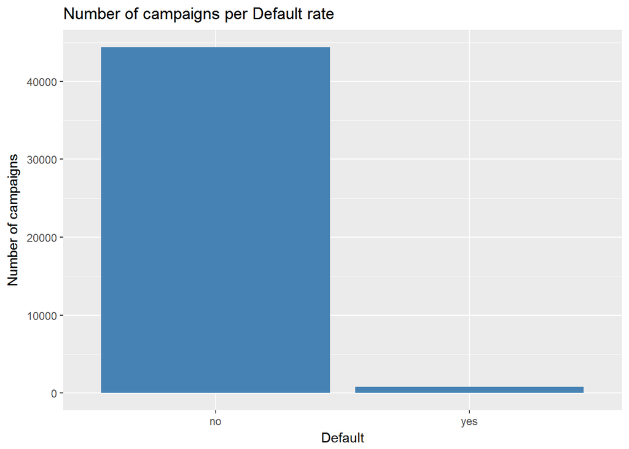

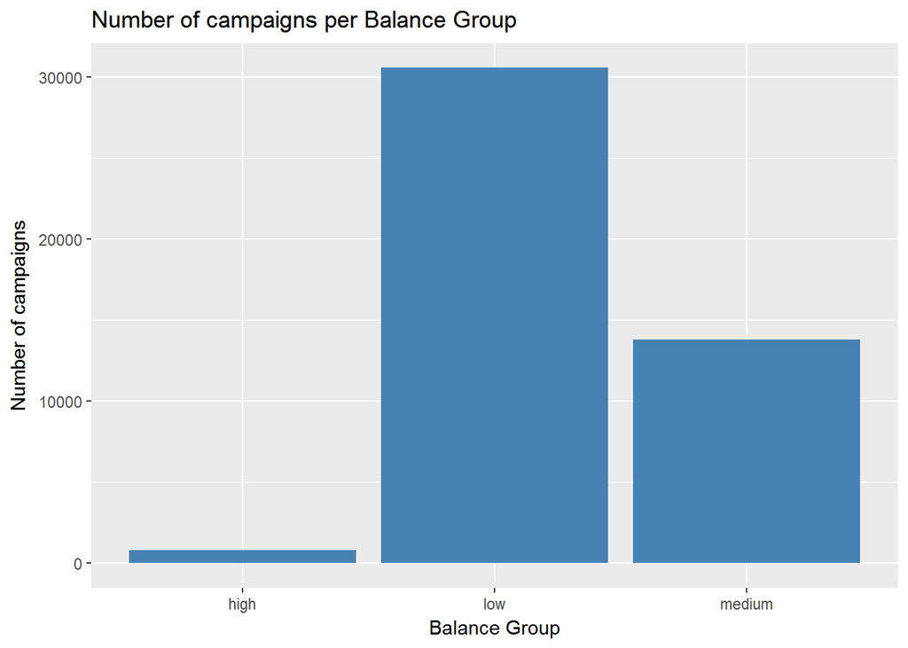

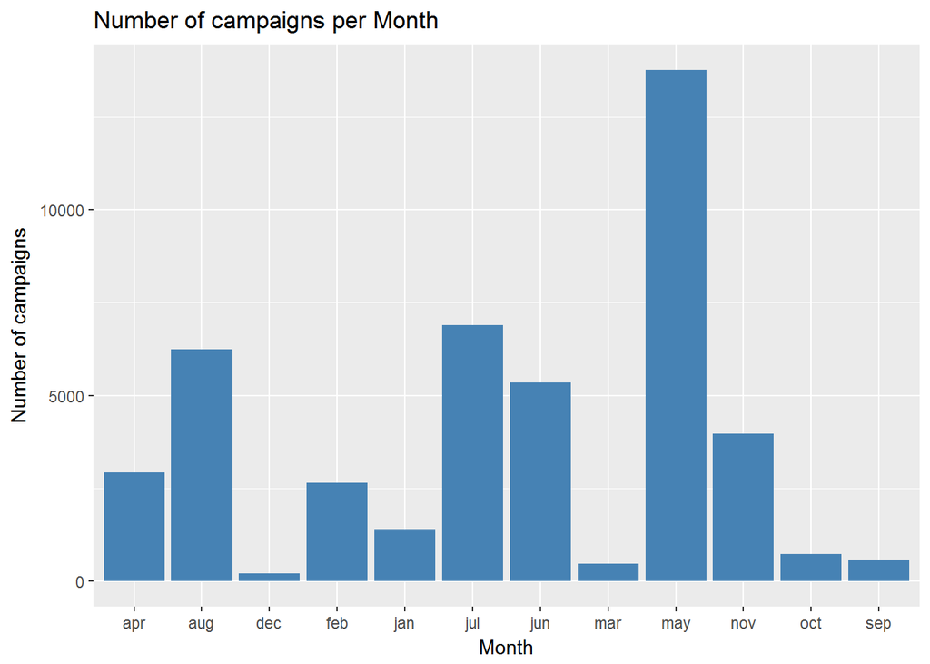

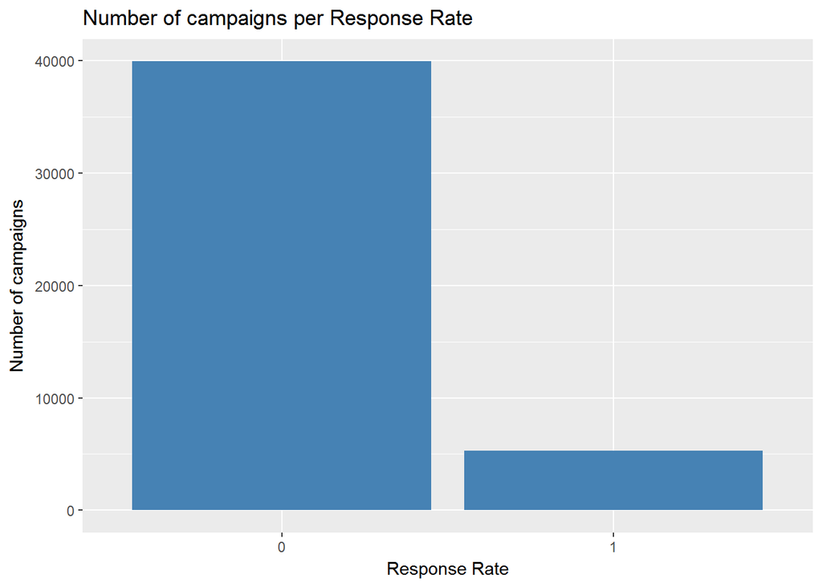